# 200010036_Lab_10_Naive_Bayes

## LAB 10 : Naive Bayes Classifier

1. Binary Classification using Naive Bayes Classifier
2. Sentiment Analysis using Naive Bayes

```python
import numpy as np
import matplotlib.pyplot as plt
```

## Binary Classification using Naive Bayes Classifier

Useful References :

1. https://machinelearningmastery.com/naive-bayes-classifier-scratch-python/
2. https://www.analyticsvidhya.com/blog/2021/01/a-guide-to-the-naive-bayes-algorithm/
3. https://towardsdatascience.com/implementing-naive-bayes-algorithm-from-scratch-python-c6880cfc9c41

**Note : The goal of this experiment is to perform and understand Naive Bayes classification by applying it on the below dataset, you can either fill in the below functions to get the result or you can create a class of your own using the above references to perform classification**

1. Generation of 2D training data

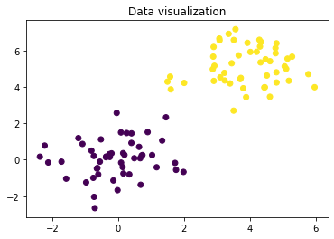

```python
mean1=np.array([0,0])
mean2=np.array([4,5])
var=np.array([[1,0.1],[0.1,1]])
np.random.seed(0)
data1=np.random.multivariate_normal(mean1,var,50)
data2=np.random.multivariate_normal(mean2,var,50)
data=np.concatenate((data1,data2))
label=np.concatenate((np.zeros(data1.shape[0]),np.ones(data2.shape[0])))

plt.figure()
plt.scatter(data[:,0],data[:,1],c=label)
plt.title('Data visualization')
```

```python
class NaiveBayes:
	def __init__(self):
		self.mean1=None
		self.mean2=None
		self.var1=None
		self.var2=None
		self.prior1=None
		self.prior2=None
		self.min = 1e-30

	def fit(self,data,label):
		self.mean1=np.mean(data[label==0],axis=0)
		self.mean2=np.mean(data[label==1],axis=0)
		self.var1=np.var(data[label==0],axis=0)
		self.var2=np.var(data[label==1],axis=0)
		self.prior1=(np.sum(label==0))/data.shape[0]
		self.prior2=(np.sum(label==1))/data.shape[0]

	def predict(self,data):
		p1=np.exp(-np.sum((data-self.mean1)**2/(self.var1+self.min),axis=1)/2)/np.sqrt((np.prod(self.var1)+self.min)*2*np.pi)
		p2=np.exp(-np.sum((data-self.mean2)**2/(self.var2+self.min),axis=1)/2)/np.sqrt((np.prod(self.var2)+self.min)*2*np.pi)
		p1*=self.prior1
		p2*=self.prior2
		return (p1<p2).astype(int), (p1, p2)
```

1. Test the model using some samples

```
Test Data Size :  20
```

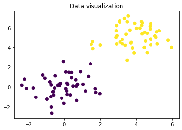

```python
## Test Data Generation

mean1=np.array([0,0])
mean2=np.array([4,5])
var=np.array([[1,0.1],[0.1,1]])
np.random.seed(0)
data1=np.random.multivariate_normal(mean1,var,10)
data2=np.random.multivariate_normal(mean2,var,10)
test_data=np.concatenate((data1,data2))
y_test=np.concatenate((np.zeros(data1.shape[0]),np.ones(data2.shape[0])))
print('Test Data Size : ',test_data.shape[0])
plt.figure()
plt.scatter(data[:,0],data[:,1],c=label)
plt.title('Data visualization')
```

Testing for a sample point

```python
naiveBayes = NaiveBayes()
naiveBayes.fit(data,label)
_, (p1, p2) = naiveBayes.predict(test_data[0,:].reshape(1,-1))

print(f'Class Probabilites for the first sample of test dataset: 0 -> {p1} and 1 -> {p2}')
```

```
Class Probabilites for the first sample of test dataset: 0 -> [0.03558711] and 1 -> [2.0887671e-15]
```

**As seen above the class probability for the 1st sample is given, we can observe that probability is higher for class 0 than 1 and hence imply that this datapoint belongs to class 0**

Now Calculate the class probabilities for all the data points in the test dataset and calculate the accuracy by comparing the predicted labels with the true test labels

```python
preds, _ = naiveBayes.predict(test_data)

print(f'Accuracy: {np.sum(preds == y_test)/len(y_test)*100:.2f}%')
```

```
Accuracy: 100.00%
```

```python
# Use gaussian naive bayes from sklearn
from sklearn.naive_bayes import GaussianNB

gnb = GaussianNB()
gnb.fit(data, label)
preds = gnb.predict(test_data)

print(f'Accuracy: {np.sum(preds == y_test)/len(y_test)*100:.2f}%')
```

```
Accuracy: 100.00%
```

## Sentiment Analysis using Naive Bayes Classifier

Go through the following [article](https://www.analyticsvidhya.com/blog/2021/07/performing-sentiment-analysis-with-naive-bayes-classifier/) and implement the same

**Keypoints** :

**Note : The goal of this experiment is to explore a practical use case of Naive bayes classifier as well as to understand how to deal with textual data, you can follow any other open source implemetations of sentiment analysis using naive bayes also**

Other References :

1. https://towardsdatascience.com/sentiment-analysis-introduction-to-naive-bayes-algorithm-96831d77ac91
2. https://gist.github.com/CateGitau/6608912ca92733036c090676c61c13cd

```python
# Get data (only run once)
# !wget https://github.com/Hrd2D/Sentiment-analysis-on-Google-Play-store-apps-reviews/raw/master/google_play_store_apps_reviews_training.csv
```

```python
import pandas as pd
```

```python
# Load data
data = pd.read_csv('google_play_store_apps_reviews_training.csv')

# Drop package name
data = data.drop('package_name', axis=1)

# Remove empty space and convert to lower case
data['review'] = data['review'].str.strip().str.lower()

data.head()
```

|  | review | polarity |
| --- | --- | --- |
| 0 | privacy at least put some option appear offlin... | 0 |
| 1 | messenger issues ever since the last update, i... | 0 |
| 2 | profile any time my wife or anybody has more t... | 0 |
| 3 | the new features suck for those of us who don'... | 0 |
| 4 | forced reload on uploading pic on replying com... | 0 |

```python
from sklearn.model_selection import train_test_split
from sklearn.feature_extraction.text import CountVectorizer

# Train test split
X_train, X_test, y_train, y_test = train_test_split(data['review'], data['polarity'], test_size=0.2, random_state=10)

# Vectorize the data as count vectors
countVectorizer = CountVectorizer(stop_words='english')

X_train = countVectorizer.fit_transform(X_train).toarray()
X_test = countVectorizer.transform(X_test).toarray()
```

```python
# Using my code
naiveBayes = NaiveBayes()
naiveBayes.fit(X_train, y_train)

preds, _ = naiveBayes.predict(X_test)

print(f'Accuracy: {np.sum(preds == y_test)/len(y_test)*100:.2f}%')
```

```
Accuracy: 77.09%
```

```python
# Using sklearn
naiveBayes = GaussianNB()
naiveBayes.fit(X_train, y_train)

preds = naiveBayes.predict(X_test)

print(f'Accuracy: {np.sum(preds == y_test)/len(y_test)*100:.2f}%')
```

```
Accuracy: 77.65%
```